# Employer Mental Health Support in Tech

Company size, benefit awareness, and treatment-seeking

Author

Varun Mohan

## Introduction

Employers can offer mental health support in several ways. These include insurance coverage, care options, wellness programs, information resources, anonymity protections, and accessible medical leave. This report uses the 2014 OSMI Mental Health in Tech Survey to ask three questions:

1. Does the level of employer support differ by company size?
2. Do workers know what support they have, and does that awareness depend on company size?
3. Are workers with more employer support more likely to have sought treatment?

```r
library(dplyr)
library(tidyr)
library(ggplot2)
library(scales)
library(broom)

theme_set(theme_minimal(base_size = 12) +
  theme(plot.title = element_text(face = "bold"), legend.position = "bottom"))

size_levels <- c("1-5", "6-25", "26-100", "100-500", "500-1000", "More than 1000")

osmi <- read.csv("data/survey.csv") |>
  filter(tech_company == "Yes") |>
  mutate(
    no_employees = factor(no_employees, levels = size_levels),
    benefits = factor(benefits, levels = c("Yes", "No", "Don't know")),
    support = (benefits == "Yes") + (care_options == "Yes") +
      (wellness_program == "Yes") + (seek_help == "Yes") +
      (anonymity == "Yes") + (leave %in% c("Very easy", "Somewhat easy")),
    treat = as.integer(treatment == "Yes")
  )

n_resp <- nrow(osmi)
n_countries <- n_distinct(osmi$Country)
```

## Data

The survey was collected by Open Sourcing Mental Illness in 2014. After restricting to respondents who work at a tech company, the sample contains 1031 respondents from 46 countries.

To measure support, I built a support index from 0 to 6. A worker gets one point for each of the following:

| Component | Survey item | Counts as support |
| --- | --- | --- |
| Insurance benefits | `benefits` | Yes |
| Care options known | `care_options` | Yes |
| Wellness program | `wellness_program` | Yes |
| Information resources | `seek_help` | Yes |
| Anonymity protected | `anonymity` | Yes |
| Accessible leave | `leave` | Very easy or Somewhat easy |

“Don’t know” responses score zero. Support that a worker doesn’t know about can’t be used, so the index measures usable support rather than formal policy.

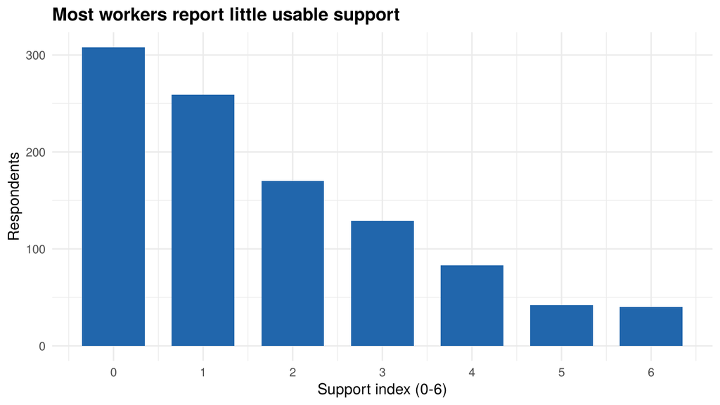

Figure 1: Distribution of the support index

```r
ggplot(osmi, aes(support)) +
  geom_bar(fill = "#2166ac", width = 0.7) +
  scale_x_continuous(breaks = 0:6) +
  labs(title = "Most workers report little usable support",
       x = "Support index (0-6)", y = "Respondents")
```

The index is right-skewed: 55% of respondents score 0 or 1, and the mean is 1.71.

## Q1: Does support differ by company size?

```r
size_summary <- osmi |>
  group_by(no_employees) |>
  summarise(n = n(), mean = mean(support), sd = sd(support),
            se = sd / sqrt(n), .groups = "drop")

knitr::kable(size_summary, digits = 2,
             col.names = c("Company size", "n", "Mean", "SD", "SE"))
```

| Company size | n | Mean | SD | SE |
| --- | --- | --- | --- | --- |
| 1-5 | 152 | 1.61 | 1.55 | 0.13 |
| 6-25 | 268 | 1.29 | 1.33 | 0.08 |
| 26-100 | 242 | 1.55 | 1.62 | 0.10 |
| 100-500 | 136 | 1.56 | 1.48 | 0.13 |
| 500-1000 | 41 | 1.98 | 1.94 | 0.30 |
| More than 1000 | 192 | 2.65 | 1.97 | 0.14 |

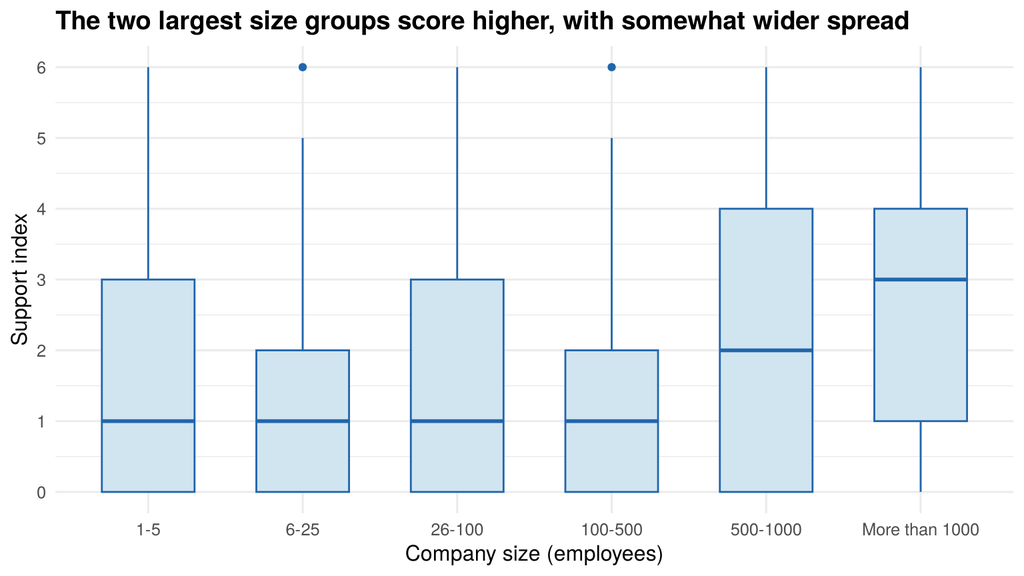

Figure 2: Spread of the support index by company size

```r
ggplot(osmi, aes(no_employees, support)) +
  geom_boxplot(fill = "#d1e5f0", color = "#2166ac", width = 0.6) +
  scale_y_continuous(breaks = 0:6) +
  labs(title = "The two largest size groups score higher, with somewhat wider spread",
       x = "Company size (employees)", y = "Support index")
```

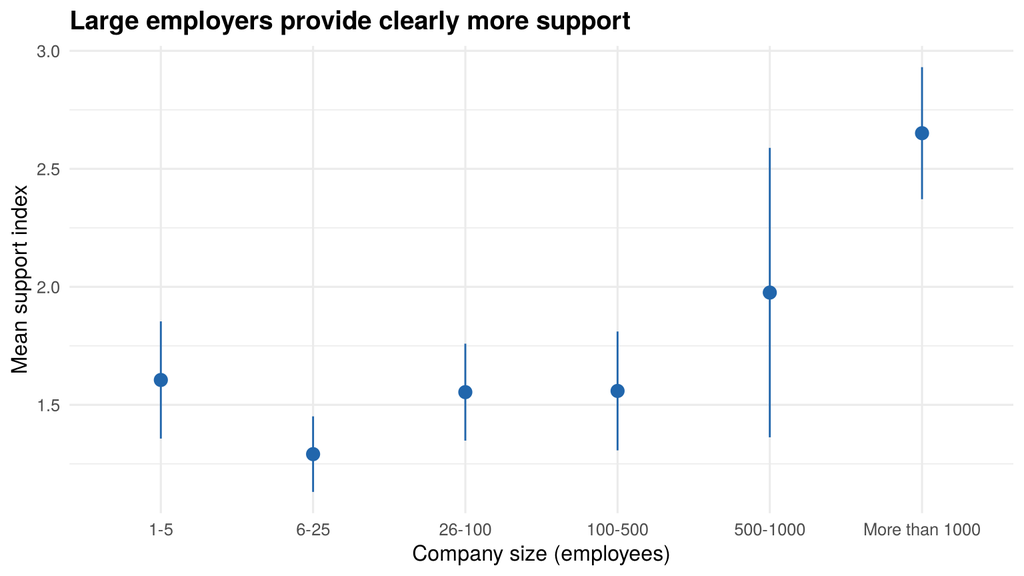

Figure 3: Mean support index by company size, with 95% confidence intervals

```r
ggplot(size_summary, aes(no_employees, mean)) +
  geom_pointrange(aes(ymin = mean - qt(0.975, n - 1) * se,
                      ymax = mean + qt(0.975, n - 1) * se),
                  color = "#2166ac", size = 0.6) +
  labs(title = "Large employers provide clearly more support",
       x = "Company size (employees)", y = "Mean support index")
```

```r
sd_ratio <- max(size_summary$sd) / min(size_summary$sd)
welch <- oneway.test(support ~ no_employees, data = osmi, var.equal = FALSE)
kw <- kruskal.test(support ~ no_employees, data = osmi)
pairs <- pairwise.t.test(osmi$support, osmi$no_employees,
                         pool.sd = FALSE, p.adjust.method = "holm")
```

The group standard deviations range from 1.33 to 1.97, a ratio of 1.48. That is under the common rule of thumb of 2, and the boxplots show roughly comparable spreads. However, group sizes are very unequal (41 to 268 respondents), which makes the classic ANOVA sensitive to even moderate differences in variance. I therefore used Welch’s one-way ANOVA, which does not assume equal variances.

- **Welch’s ANOVA:** F(5, 276.4) = 14.1, p = 2.8e-12
- **Kruskal-Wallis (robustness check):** χ²(5) = 62.1, p = 4.4e-12

The index is a bounded count rather than a continuous measure, so the Kruskal-Wallis test confirms the result without assuming normality. Both tests agree.

```r
knitr::kable(pairs$p.value, digits = 3)
```

Pairwise Welch t-tests, Holm-adjusted p-values

|  | 1-5 | 6-25 | 26-100 | 100-500 | 500-1000 |
| --- | --- | --- | --- | --- | --- |
| 6-25 | 0.379 | NA | NA | NA | NA |
| 26-100 | 1.000 | 0.428 | NA | NA | NA |
| 100-500 | 1.000 | 0.543 | 1 | NA | NA |
| 500-1000 | 1.000 | 0.379 | 1 | 1 | NA |
| More than 1000 | 0.000 | 0.000 | 0 | 0 | 0.428 |

Post-hoc tests show the effect comes from the largest employers. Companies with more than 1,000 employees differ significantly from every size group below 500. The groups from 1 to 500 employees are statistically indistinguishable from each other.

## Q2: Do workers know what benefits they have?

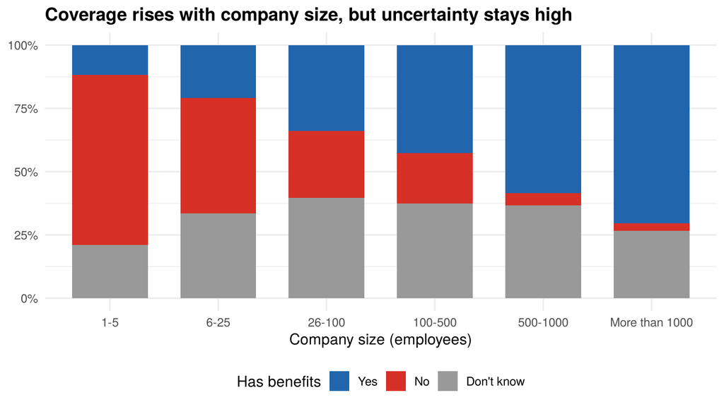

Figure 4: Reported mental health insurance benefits by company size

```r
osmi |>
  count(no_employees, benefits) |>
  group_by(no_employees) |>
  mutate(pct = n / sum(n)) |>
  ggplot(aes(no_employees, pct, fill = benefits)) +
  geom_col(width = 0.7) +
  scale_y_continuous(labels = percent) +
  scale_fill_manual(values = c("Yes" = "#2166ac", "No" = "#d73027",
                               "Don't know" = "#999999")) +
  labs(title = "Coverage rises with company size, but uncertainty stays high",
       x = "Company size (employees)", y = NULL, fill = "Has benefits")
```

```r
shares <- prop.table(table(osmi$no_employees, osmi$benefits), 1)
dk_share <- shares[, "Don't know"]
yes_small <- shares["1-5", "Yes"]
yes_large <- shares["More than 1000", "Yes"]
```

Reported coverage rises steadily with company size, from 12% at the smallest employers to 70% at companies with more than 1,000 employees.

The awareness gap is the more notable pattern. Between 21% and 40% of workers in every size group don’t know whether they have mental health coverage. Large employers mostly provide benefits, but they don’t reliably communicate them.

## Q3: Is support associated with treatment-seeking?

```r
tt <- t.test(support ~ treatment, data = osmi)

set.seed(2026)
obs_diff <- with(osmi, mean(support[treat == 1]) - mean(support[treat == 0]))
perm_diffs <- replicate(10000, {
  shuffled <- sample(osmi$treat)
  mean(osmi$support[shuffled == 1]) - mean(osmi$support[shuffled == 0])
})
perm_p <- mean(abs(perm_diffs) >= abs(obs_diff))
```

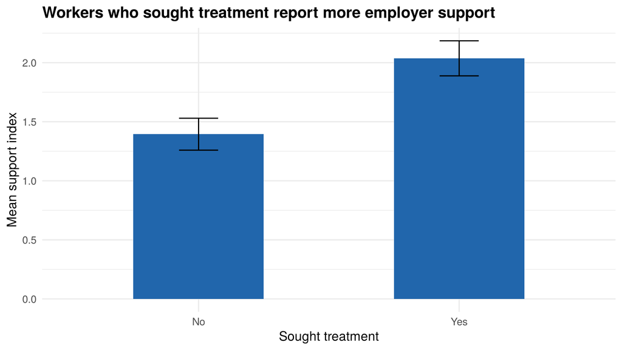

Figure 5: Support index by treatment status

```r
osmi |>
  group_by(treatment) |>
  summarise(n = n(), mean = mean(support), se = sd(support) / sqrt(n)) |>
  ggplot(aes(treatment, mean)) +
  geom_col(fill = "#2166ac", width = 0.5) +
  geom_errorbar(aes(ymin = mean - 1.96 * se, ymax = mean + 1.96 * se), width = 0.15) +
  labs(title = "Workers who sought treatment report more employer support",
       x = "Sought treatment", y = "Mean support index")
```

Workers who sought treatment had a mean support index of 2.04, compared with 1.39 for those who didn’t.

- **Welch two-sample t-test:** t = 6.27, df = 1019.7, p = 5.2e-10. The 95% CI for the difference is 0.44 to 0.84 points.
- **Permutation test (10,000 shuffles):** none of the permuted differences was as large as the observed one (p < 0.0001).

The permutation test makes no distributional assumptions, so it confirms the t-test result.

### Controlling for other factors

Family history of mental illness is a strong driver of treatment-seeking and could confound the comparison above. A logistic regression estimates the association between support and treatment while holding family history, company size, and remote work constant.

```r
fit <- glm(treat ~ support + family_history + no_employees + remote_work,
           data = osmi, family = binomial)

or_table <- tidy(fit, exponentiate = TRUE, conf.int = TRUE, conf.method = "Wald") |>
  filter(term != "(Intercept)")

knitr::kable(or_table |> select(term, estimate, conf.low, conf.high, p.value),
             digits = 3,
             col.names = c("Term", "Odds ratio", "95% CI low", "95% CI high", "p"))
```

| Term | Odds ratio | 95% CI low | 95% CI high | p |
| --- | --- | --- | --- | --- |
| support | 1.273 | 1.168 | 1.390 | 0.000 |
| family_historyYes | 5.501 | 4.145 | 7.351 | 0.000 |
| no_employees6-25 | 0.847 | 0.539 | 1.332 | 0.472 |
| no_employees26-100 | 1.030 | 0.651 | 1.633 | 0.899 |
| no_employees100-500 | 0.969 | 0.575 | 1.632 | 0.906 |
| no_employees500-1000 | 0.565 | 0.255 | 1.231 | 0.154 |
| no_employeesMore than 1000 | 0.752 | 0.455 | 1.241 | 0.266 |
| remote_workYes | 1.143 | 0.846 | 1.544 | 0.383 |

```r
or_support <- or_table |> filter(term == "support")
or_family <- or_table |> filter(term == "family_historyYes")
```

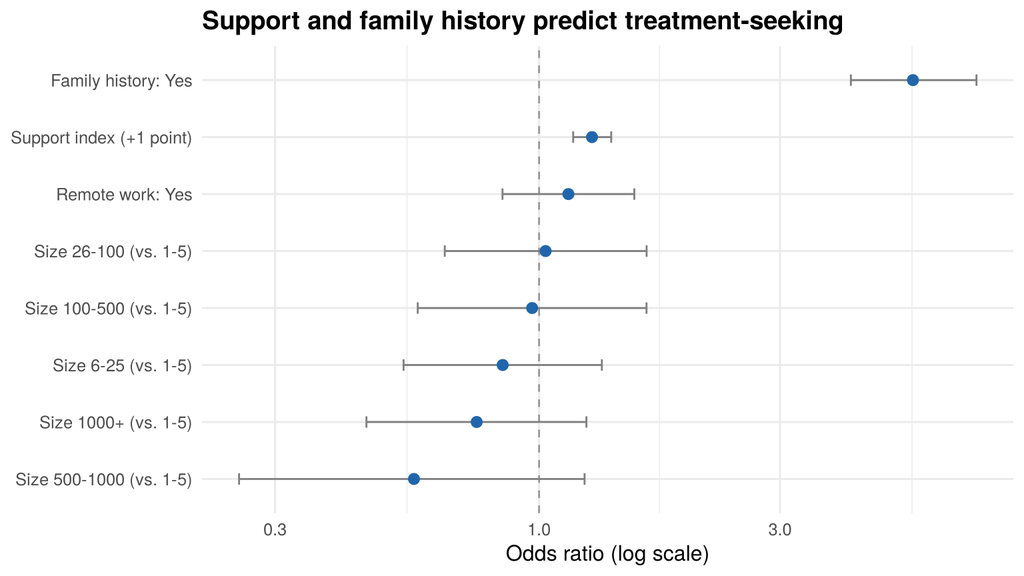

Figure 6: Odds ratios for having sought treatment (log scale)

```r
or_table |>
  mutate(term = recode(term,
    support = "Support index (+1 point)",
    family_historyYes = "Family history: Yes",
    remote_workYes = "Remote work: Yes",
    `no_employees6-25` = "Size 6-25 (vs. 1-5)",
    `no_employees26-100` = "Size 26-100 (vs. 1-5)",
    `no_employees100-500` = "Size 100-500 (vs. 1-5)",
    `no_employees500-1000` = "Size 500-1000 (vs. 1-5)",
    `no_employeesMore than 1000` = "Size 1000+ (vs. 1-5)")) |>
  ggplot(aes(estimate, reorder(term, estimate))) +
  geom_vline(xintercept = 1, linetype = "dashed", color = "grey60") +
  geom_errorbarh(aes(xmin = conf.low, xmax = conf.high), height = 0.2, color = "grey50") +
  geom_point(size = 2.5, color = "#2166ac") +
  scale_x_log10() +
  labs(title = "Support and family history predict treatment-seeking",
       x = "Odds ratio (log scale)", y = NULL)
```

After adjustment, each additional point on the support index multiplies the odds of having sought treatment by 1.27 (95% CI 1.17 to 1.39). Family history has the largest effect (OR = 5.5). Company size and remote work show no significant independent association. Size matters for how much support workers receive (Q1), but once support is accounted for, size itself adds nothing.

## Conclusions

- **Support is concentrated at large employers.** Only companies with more than 1,000 employees provide meaningfully more support. Firms from 1 to 500 employees look alike.
- **Awareness is a separate problem from provision.** A sizable share of workers at every company size don’t know whether they have coverage.
- **Usable support is associated with treatment-seeking,** and the association holds after controlling for family history, company size, and remote work.

For employers, these results suggest that communicating existing benefits may matter as much as adding new ones.

## Limitations

- **Observational, cross-sectional data.** The analysis shows associations, not causal effects. Reverse causation is plausible: workers who seek treatment may learn about their benefits in the process, which would raise their support score.
- **Self-selected 2014 sample.** Respondents chose to take a mental health survey, and the data predate remote-work and post-pandemic changes in workplace mental health policy.
- **Index construction.** The six components are equally weighted, and “Don’t know” is scored as no support. Results reflect workers’ perceptions of support, not employers’ actual policies.
- **Bounded outcome.** The support index is a 0–6 count. The nonparametric checks (Kruskal-Wallis and permutation tests) agree with the parametric results.